# Tutorial with Dials and Broom

# Packages description:

## `dials`:

### • This package contains tools to create and manage values of tuning parameters and is designed to integrate well with the parsnip package.

## `broom`:

### • This package summarizes key information about models in tidy tibble()s.

### First, lets load the necessary packages:

```r
library(tidymodels)
library(tidyverse)
```

# Package tutorials:

# `dials` package

I’ll demonstrate it’s features using an existing dataset from Bruno Oliveria: “Amphibio”:  
• Link to publication: https://www.nature.com/articles/sdata2017123  
• Link to data: https://ndownloader.figstatic.com/files/8828578

## Amphibio data

Download data:

```r
# install.packages("downloader")
# library(downloader)
#
# url <- "https://ndownloader.figstatic.com/files/8828578"
# download(url, dest="dial_broom/amphibio.zip", mode="wb")
# unzip("dial_broom/amphibio.zip", exdir = "./dial_broom")

library(readr)

amphibio_raw <- read_csv("AmphiBIO_v1.csv")
library(skimr)

skim(amphibio_raw)
```

Data summary

| Name | amphibio_raw |
| --- | --- |
| Number of rows | 6776 |
| Number of columns | 38 |
| _______________________ |  |
| Column type frequency: |  |
| character | 6 |
| logical | 1 |
| numeric | 31 |
| ________________________ |  |
| Group variables | None |

**Variable type: character**

| skim_variable | n_missing | complete_rate | min | max | empty | n_unique | whitespace |
| --- | --- | --- | --- | --- | --- | --- | --- |
| id | 0 | 1.00 | 7 | 7 | 0 | 6776 | 0 |
| Order | 0 | 1.00 | 5 | 11 | 0 | 3 | 0 |
| Family | 0 | 1.00 | 7 | 20 | 0 | 61 | 0 |
| Genus | 0 | 1.00 | 4 | 17 | 0 | 531 | 0 |
| Species | 0 | 1.00 | 9 | 34 | 0 | 6776 | 0 |
| OBS | 6651 | 0.02 | 13 | 86 | 0 | 53 | 0 |

**Variable type: logical**

| skim_variable | n_missing | complete_rate | mean | count |
| --- | --- | --- | --- | --- |
| Fruits | 6774 | 0 | 1 | TRU: 2 |

**Variable type: numeric**

| skim_variable | n_missing | complete_rate | mean | sd | p0 | p25 | p50 | p75 | p100 | hist |
| --- | --- | --- | --- | --- | --- | --- | --- | --- | --- | --- |
| Fos | 6053 | 0.11 | 1.00 | 0.00 | 1.00 | 1.0 | 1.00 | 1.00 | 1.0 | ▁▁▇▁▁ |
| Ter | 1104 | 0.84 | 1.00 | 0.00 | 1.00 | 1.0 | 1.00 | 1.00 | 1.0 | ▁▁▇▁▁ |
| Aqu | 2810 | 0.59 | 1.00 | 0.00 | 1.00 | 1.0 | 1.00 | 1.00 | 1.0 | ▁▁▇▁▁ |
| Arb | 4347 | 0.36 | 1.00 | 0.00 | 1.00 | 1.0 | 1.00 | 1.00 | 1.0 | ▁▁▇▁▁ |
| Leaves | 6752 | 0.00 | 1.00 | 0.00 | 1.00 | 1.0 | 1.00 | 1.00 | 1.0 | ▁▁▇▁▁ |
| Flowers | 6772 | 0.00 | 1.00 | 0.00 | 1.00 | 1.0 | 1.00 | 1.00 | 1.0 | ▁▁▇▁▁ |
| Seeds | 6772 | 0.00 | 1.00 | 0.00 | 1.00 | 1.0 | 1.00 | 1.00 | 1.0 | ▁▁▇▁▁ |
| Arthro | 5534 | 0.18 | 1.00 | 0.00 | 1.00 | 1.0 | 1.00 | 1.00 | 1.0 | ▁▁▇▁▁ |
| Vert | 6657 | 0.02 | 1.00 | 0.00 | 1.00 | 1.0 | 1.00 | 1.00 | 1.0 | ▁▁▇▁▁ |
| Diu | 5876 | 0.13 | 1.00 | 0.00 | 1.00 | 1.0 | 1.00 | 1.00 | 1.0 | ▁▁▇▁▁ |
| Noc | 5156 | 0.24 | 1.00 | 0.00 | 1.00 | 1.0 | 1.00 | 1.00 | 1.0 | ▁▁▇▁▁ |
| Crepu | 6608 | 0.02 | 1.00 | 0.00 | 1.00 | 1.0 | 1.00 | 1.00 | 1.0 | ▁▁▇▁▁ |
| Wet_warm | 5997 | 0.11 | 1.00 | 0.00 | 1.00 | 1.0 | 1.00 | 1.00 | 1.0 | ▁▁▇▁▁ |
| Wet_cold | 6625 | 0.02 | 1.00 | 0.00 | 1.00 | 1.0 | 1.00 | 1.00 | 1.0 | ▁▁▇▁▁ |
| Dry_warm | 6572 | 0.03 | 1.00 | 0.00 | 1.00 | 1.0 | 1.00 | 1.00 | 1.0 | ▁▁▇▁▁ |
| Dry_cold | 6735 | 0.01 | 1.00 | 0.00 | 1.00 | 1.0 | 1.00 | 1.00 | 1.0 | ▁▁▇▁▁ |
| Body_mass_g | 6185 | 0.09 | 94.56 | 1093.77 | 0.16 | 2.6 | 9.29 | 31.83 | 26000.0 | ▇▁▁▁▁ |
| Age_at_maturity_min_y | 6392 | 0.06 | 2.14 | 1.18 | 0.25 | 1.0 | 2.00 | 3.00 | 7.0 | ▇▇▆▁▁ |
| Age_at_maturity_max_y | 6392 | 0.06 | 2.96 | 1.69 | 0.30 | 2.0 | 3.00 | 4.00 | 12.0 | ▇▇▂▁▁ |
| Body_size_mm | 1549 | 0.77 | 66.65 | 91.47 | 8.40 | 29.0 | 43.00 | 69.15 | 1520.0 | ▇▁▁▁▁ |
| Size_at_maturity_min_mm | 6529 | 0.04 | 56.63 | 55.57 | 8.80 | 27.5 | 43.00 | 58.00 | 350.0 | ▇▁▁▁▁ |
| Size_at_maturity_max_mm | 6528 | 0.04 | 67.46 | 66.34 | 10.10 | 32.0 | 50.00 | 75.50 | 400.0 | ▇▁▁▁▁ |
| Longevity_max_y | 6417 | 0.05 | 11.68 | 9.86 | 0.17 | 6.0 | 10.00 | 15.00 | 121.8 | ▇▁▁▁▁ |
| Litter_size_min_n | 5153 | 0.24 | 530.87 | 1575.73 | 1.00 | 18.0 | 80.00 | 300.00 | 25000.0 | ▇▁▁▁▁ |
| Litter_size_max_n | 5153 | 0.24 | 1033.70 | 2955.30 | 1.00 | 30.0 | 186.00 | 700.00 | 45054.0 | ▇▁▁▁▁ |
| Reproductive_output_y | 2344 | 0.65 | 1.03 | 0.43 | 0.08 | 1.0 | 1.00 | 1.00 | 15.0 | ▇▁▁▁▁ |
| Offspring_size_min_mm | 5446 | 0.20 | 2.45 | 1.57 | 0.20 | 1.4 | 2.00 | 3.00 | 20.0 | ▇▁▁▁▁ |
| Offspring_size_max_mm | 5446 | 0.20 | 2.86 | 1.94 | 0.40 | 1.6 | 2.30 | 3.50 | 25.0 | ▇▁▁▁▁ |
| Dir | 1079 | 0.84 | 0.30 | 0.46 | 0.00 | 0.0 | 0.00 | 1.00 | 1.0 | ▇▁▁▁▃ |
| Lar | 1079 | 0.84 | 0.69 | 0.46 | 0.00 | 0.0 | 1.00 | 1.00 | 1.0 | ▃▁▁▁▇ |
| Viv | 1079 | 0.84 | 0.01 | 0.10 | 0.00 | 0.0 | 0.00 | 0.00 | 1.0 | ▇▁▁▁▁ |

The data consist of natural history information of amphibians, including habitat types, diet, size, ect…

Here’s the breakdown of taxonomic spread in the data: • Order: N = 3  
• Family: N = 61  
• Genera: N = 531  
• Species: N = 6776

There are also a lot of missing data, and what data do exist are wildly different scales. We’ll clean this up:

```r
# Check how many NA's for each row
amphibio <- amphibio_raw %>%
  select("Order"
         ,"Body_mass_g"
         ,"Body_size_mm"
         ,"Litter_size_min_n"
         ,"Litter_size_max_n"
         ,"Reproductive_output_y"
         ) %>%
  na.omit %>%
  mutate(Body_mass_g = log(Body_mass_g),
         Body_size_mm = log(Body_size_mm),
         Litter_size_min_n = log(Litter_size_min_n),
         Litter_size_max_n = log(Litter_size_max_n),
         Reproductive_output_y = log(Reproductive_output_y)) %>%
  filter(!Order == "Gymnophiona")

amphibio %>%
  group_by(Order) %>%
  summarize(n = n())
```

```
## # A tibble: 2 x 2
##   Order       n
##   <chr>   <int>
## 1 Anura     355
## 2 Caudata    56
```

Now let’s have another look at the data:

```r
# Check column nas
amphibio %>% skim()
```

Data summary

| Name | Piped data |
| --- | --- |
| Number of rows | 411 |
| Number of columns | 6 |
| _______________________ |  |
| Column type frequency: |  |
| character | 1 |
| numeric | 5 |
| ________________________ |  |
| Group variables | None |

**Variable type: character**

| skim_variable | n_missing | complete_rate | min | max | empty | n_unique | whitespace |
| --- | --- | --- | --- | --- | --- | --- | --- |
| Order | 0 | 1 | 5 | 7 | 0 | 2 | 0 |

**Variable type: numeric**

| skim_variable | n_missing | complete_rate | mean | sd | p0 | p25 | p50 | p75 | p100 | hist |
| --- | --- | --- | --- | --- | --- | --- | --- | --- | --- | --- |
| Body_mass_g | 0 | 1 | 2.37 | 1.73 | -1.83 | 1.22 | 2.38 | 3.47 | 10.17 | ▂▇▆▁▁ |
| Body_size_mm | 0 | 1 | 4.19 | 0.69 | 2.48 | 3.69 | 4.13 | 4.61 | 7.22 | ▂▇▆▁▁ |
| Litter_size_min_n | 0 | 1 | 5.05 | 1.95 | 0.00 | 3.69 | 5.26 | 6.32 | 9.62 | ▁▅▇▅▂ |
| Litter_size_max_n | 0 | 1 | 6.03 | 1.99 | 0.00 | 4.94 | 6.11 | 7.45 | 10.72 | ▁▃▇▇▂ |
| Reproductive_output_y | 0 | 1 | 0.05 | 0.31 | -2.53 | 0.00 | 0.00 | 0.00 | 2.48 | ▁▁▇▁▁ |

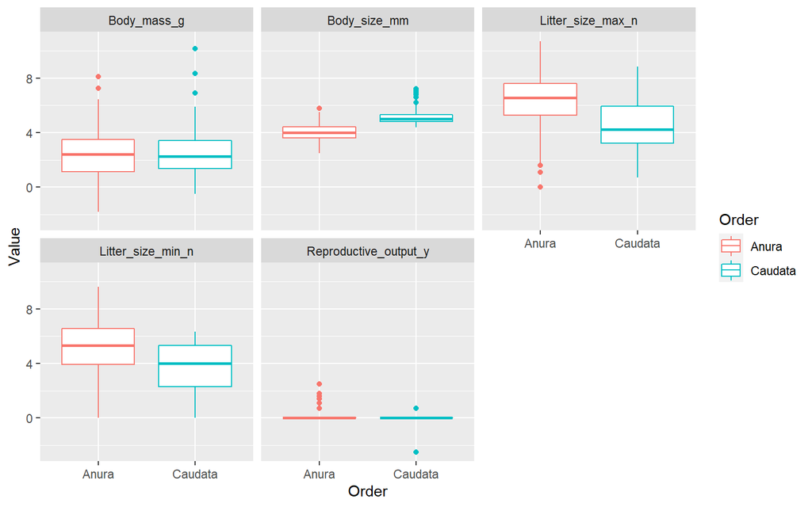

```r
amphibio %>%
  pivot_longer(!Order, names_to = "Metric", values_to = "Value") %>%
  ggplot(aes(Order, Value, col = Order)) +
    geom_boxplot() +
    facet_wrap(~Metric)
```

There are some trends in the data:  
• caudates are longer  
• anura have larger litter sizes

Given the data, one possible modeling application could be to use data to predict order using two models: knn and boosted regression trees.

To start the modeling process, we’ll use `rsamples` to split the data into training and testing sets.

```r
set.seed(42)

tidy_split <- initial_split(amphibio, prop = 0.95)
tidy_train <- training(tidy_split)
tidy_test <- testing(tidy_split)
tidy_kfolds <- vfold_cv(tidy_train)
```

We can use `recipes` to preprocess the data:

```r
# Recipes package
## For preprocessing, feature engineering, and feature elimination
tidy_rec <- recipe(Order ~ ., data = tidy_train) %>%
  step_dummy(all_nominal(), -all_outcomes()) %>%
  step_normalize(all_predictors()) %>%
  prep()
```

Now that we’ve created a recipe to process the data for modeling, we can use `parsnip` to model the data:

First, let’s have a look at the model’s description

```r
library("webshot")
# ?boost_tree
knitr::include_url("https://parsnip.tidymodels.org/reference/boost_tree.html")
```

[interactive chart not shown]

## `boost_tree()`

### Description

`boost_tree()` defines a model that creates a series of decision trees forming an ensemble. Each tree depends on the results of previous trees. All trees in the ensemble are combined to produce a final prediction.

There are different ways to fit this model. See the engine-specific pages for more details:

• xgboost (default)  
• C5.0  
• spark

```r
# ?nearest_neighbor
knitr::include_url("https://parsnip.tidymodels.org/reference/nearest_neighbor.html")
```

[interactive chart not shown]

## `nearest_neighbor()`:

### defines a model that uses the K most similar data points from the training set to predict new samples.

### There are different ways to fit this model. See the engine-specific pages for more details:

• kknn (default)

Now, let’s fit the models:

```r
# Parsnip package
## Standardized api for creating models
tidy_boosted_model <- boost_tree(trees = tune(),
                                min_n = tune(),
                                learn_rate = tune()) %>%
  set_mode("classification") %>%
  set_engine("xgboost")

tidy_knn_model <- nearest_neighbor(neighbors = tune()) %>%
  set_mode("classification") %>%
  set_engine("kknn")
```

Our basic model recipe is complete, but now we want to use `dials` to tune parameters.

For boosted regression trees, there are 3 basic parameters:

```r
parameters(tidy_boosted_model)
```

```
## Collection of 3 parameters for tuning
##
##  identifier       type    object
##       trees      trees nparam[+]
##       min_n      min_n nparam[+]
##  learn_rate learn_rate nparam[+]
```

• `trees`: An integer for the number of trees contained in the ensemble.  
• `min_n`: An integer for the minimum number of data points in a node that is required for the node to be split further.  
• `learn_rate`: A number for the rate at which the boosting algorithm adapts from iteration-to-iteration (specific engines only).

Knn has a single parameter to tune: the neighbors

```r
parameters(tidy_knn_model)
```

```
## Collection of 1 parameters for tuning
##
##  identifier      type    object
##   neighbors neighbors nparam[+]
```

• `neighbors`: A single integer for the number of neighbors to consider (often called k). For kknn, a value of 5 is used if neighbors is not specified.

So, we can use `dials` to set the possible parameter values, which can then be tuned using `tune`.

```r
# Dials creates the parameter grids
# Tune applies the parameter grid to the models
# Dials pacakge
boosted_params <- 5
knn_params <- 10

?grid_regular
```

```
## starting httpd help server ... done
```

```r
boosted_grid <- grid_regular(parameters(tidy_boosted_model), levels = boosted_params)
boosted_grid
```

```
## # A tibble: 125 x 3
##    trees min_n   learn_rate
##    <int> <int>        <dbl>
##  1     1     2 0.0000000001
##  2   500     2 0.0000000001
##  3  1000     2 0.0000000001
##  4  1500     2 0.0000000001
##  5  2000     2 0.0000000001
##  6     1    11 0.0000000001
##  7   500    11 0.0000000001
##  8  1000    11 0.0000000001
##  9  1500    11 0.0000000001
## 10  2000    11 0.0000000001
## # ... with 115 more rows
```

```r
knn_grid <- grid_regular(parameters(tidy_knn_model), levels = knn_params)
knn_grid
```

```
## # A tibble: 10 x 1
##    neighbors
##        <int>
##  1         1
##  2         2
##  3         4
##  4         5
##  5         7
##  6         8
##  7        10
##  8        11
##  9        13
## 10        15
```

Implement tuning grid using `tune`:

```r
# install.packages(c("xgboost", "kknn"))
library(xgboost)
library(kknn)

# Tune pacakge
# system.time(
#   boosted_tune <- tune_grid(tidy_boosted_model,
#                             tidy_rec,
#                             resamples = tidy_kfolds,
#                             grid = boosted_grid)
# )
# write_rds(boosted_tune, "boosted_tune.rds")
boosted_tune <- read_rds("boosted_tune.rds")

# system.time(
#   knn_tune <- tune_grid(tidy_knn_model,
#                         tidy_rec,
#                         resamples = tidy_kfolds,
#                         grid = knn_grid)
# )
# write_rds(knn_tune, "knn_tune.rds")
knn_tune <- read_rds("knn_tune.rds")

#Use Tune package to extract best parameters using ROC_AUC handtill
boosted_param <- boosted_tune %>% select_best("roc_auc")
knn_param <- knn_tune %>% select_best("roc_auc")
#Apply parameters to the models
tidy_boosted_model_final <- finalize_model(tidy_boosted_model, boosted_param)
tidy_knn_model_final <- finalize_model(tidy_knn_model, knn_param)
```

Now, well try different options from `dials` for parameter tuning, using two additional methods for grid specification:  
• random grid with `dials::grid_random`  
• maximum entropy grid with `dials::grid_max_entropy`

## `grid_random`

```r
boosted_grid_rand <- grid_random(parameters(tidy_boosted_model), size = boosted_params)
boosted_grid_rand
```

```
## # A tibble: 5 x 3
##   trees min_n learn_rate
##   <int> <int>      <dbl>
## 1   190    21   2.32e- 5
## 2  1816    12   3.60e- 8
## 3   293    28   3.14e-10
## 4   314     8   2.52e- 7
## 5  1363     5   5.92e- 6
```

```r
knn_grid_rand <- grid_random(parameters(tidy_knn_model), size = knn_params)
knn_grid_rand
```

```
## # A tibble: 7 x 1
##   neighbors
##       <int>
## 1         1
## 2        10
## 3         5
## 4         3
## 5        11
## 6         8
## 7         2
```

```r
# system.time(
#   boosted_tune_rand <- tune_grid(tidy_boosted_model,
#                                  tidy_rec,
#                                  resamples = tidy_kfolds,
#                                  grid = boosted_grid_rand)
# )
# write_rds(boosted_tune_rand, "boosted_tune_rand.rds")
boosted_tune_rand <- read_rds("boosted_tune_rand.rds")

# system.time(
#   knn_tune_rand <- tune_grid(tidy_knn_model,
#                              tidy_rec,
#                              resamples = tidy_kfolds,
#                              grid = knn_grid_rand)
# )
# write_rds(knn_tune_rand, "knn_tune_rand.rds")
knn_tune_rand <- read_rds("knn_tune_rand.rds")

#Use Tune package to extract best parameters using ROC_AUC handtill
boosted_param_rand <- boosted_tune_rand %>% select_best("roc_auc")
knn_param_rand <- knn_tune_rand %>% select_best("roc_auc")
```

## `grid_max_entropy`

```r
boosted_grid_maxent <- grid_max_entropy(parameters(tidy_boosted_model), size = boosted_params)
boosted_grid_maxent
```

```
## # A tibble: 5 x 3
##   trees min_n learn_rate
##   <int> <int>      <dbl>
## 1   433    25   4.27e-10
## 2  1671    13   3.28e-10
## 3  1520     3   3.21e- 6
## 4   672     3   3.06e-10
## 5  1371    22   2.32e- 5
```

```r
knn_grid_maxent <- grid_max_entropy(parameters(tidy_knn_model), size = knn_params)
knn_grid_maxent
```

```
## # A tibble: 10 x 1
##    neighbors
##        <int>
##  1         3
##  2        10
##  3         1
##  4        15
##  5        13
##  6         4
##  7         6
##  8         8
##  9         9
## 10        11
```

```r
# system.time(
#   boosted_tune_maxent <- tune_grid(tidy_boosted_model,
#                                    tidy_rec,
#                                    resamples = tidy_kfolds,
#                                    grid = boosted_grid_maxent)
# )
# write_rds(boosted_tune_maxent, "boosted_tune_maxent.rds")
boosted_tune_maxent <- read_rds("boosted_tune_maxent.rds")

# system.time(
#   knn_tune_maxent <- tune_grid(tidy_knn_model,
#                                tidy_rec,
#                                resamples = tidy_kfolds,
#                                grid = knn_grid_maxent)
# )
# write_rds(knn_tune_maxent, "knn_tune_maxent.rds")
knn_tune_maxent <- read_rds("knn_tune.rds")

#Use Tune package to extract best parameters using ROC_AUC handtill
boosted_param_maxent <- boosted_tune_maxent %>% select_best("roc_auc")
knn_param_maxent <- knn_tune_maxent %>% select_best("roc_auc")
```

## Workflow package

### For combining model, parameters, and preprocessing

```r
boosted_wf <- workflow() %>%
  add_model(tidy_boosted_model_final) %>%
  add_recipe(tidy_rec)

knn_wf <- workflow() %>%
  add_model(tidy_knn_model_final) %>%
  add_recipe(tidy_rec)
```

## Yardstick package

### For extracting metrics from the model

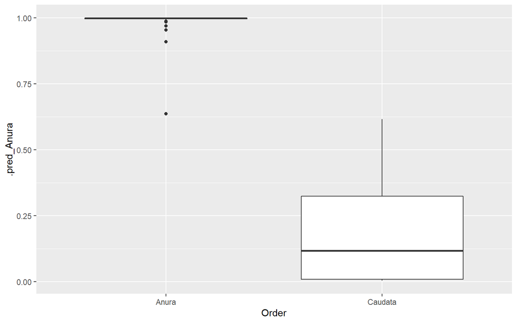

```r
boosted_res <- last_fit(boosted_wf, tidy_split)
knn_res <- last_fit(knn_wf, tidy_split)

mods <- bind_rows(
  boosted_res %>% mutate(model = "xgb"),
  knn_res %>% mutate(model = "knn")) %>%
  unnest(.metrics)

ggplot(bind_rows(mods$.predictions), aes(Order, .pred_Anura)) +
  geom_boxplot()
```

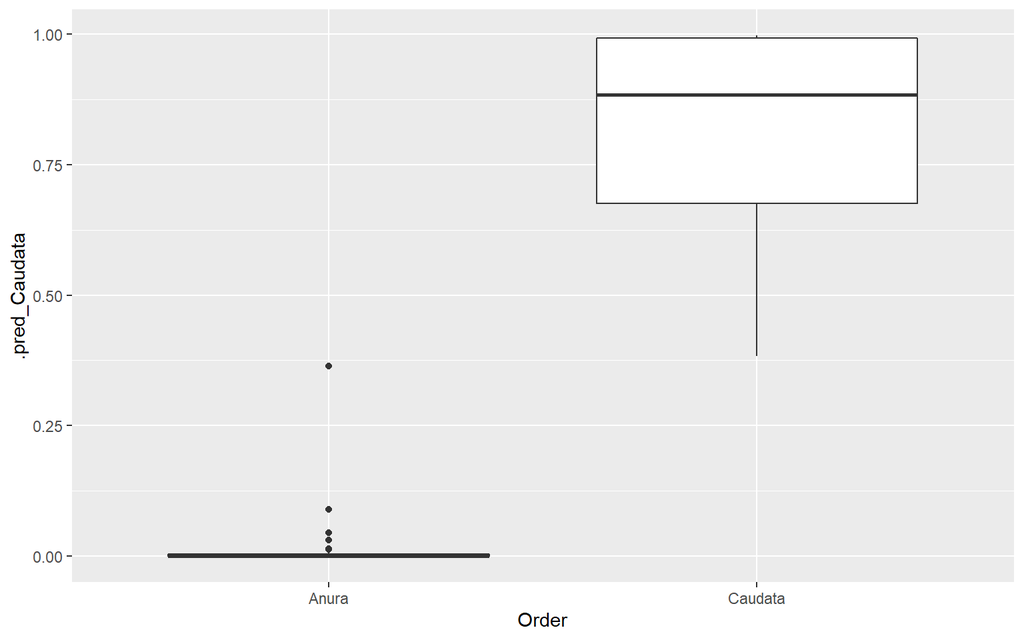

```r
ggplot(bind_rows(mods$.predictions), aes(Order, .pred_Caudata)) +
  geom_boxplot()
```

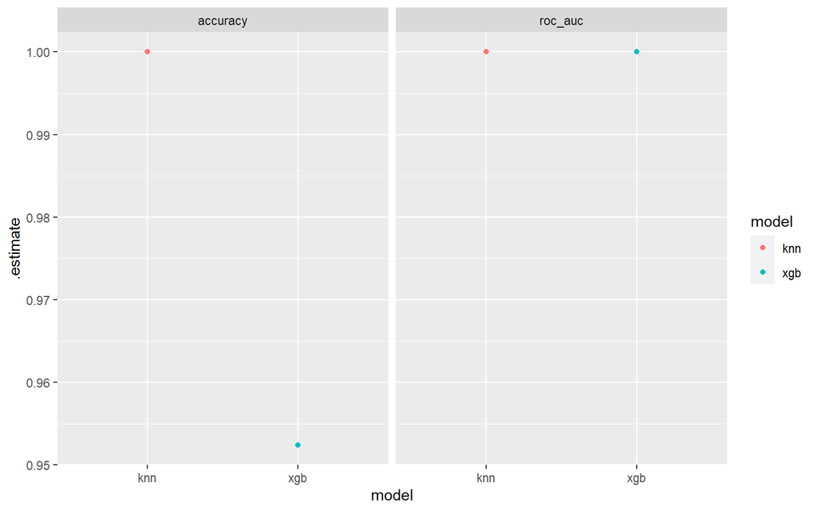

```r
ggplot(mods, aes(x = model, y = .estimate, col = model)) +
  geom_point() +
  facet_wrap(~.metric)
```

## Confusion matrix ### Visualize model predictions against truth

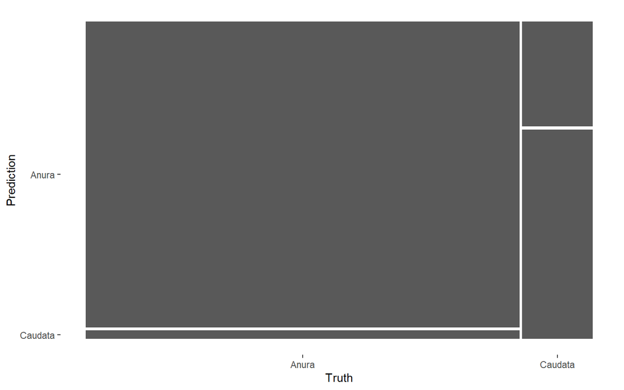

```r
boosted_res %>% unnest(.predictions) %>%
  conf_mat(truth = Order, estimate = .pred_class) %>%
  autoplot()
```

### Fit the entire data set using the final wf

```r
final_boosted_model <- fit(boosted_wf, amphibio)
```

```
## [10:03:08] WARNING: amalgamation/../src/learner.cc:1095: Starting in XGBoost 1.3.0, the default evaluation metric used with the objective 'binary:logistic' was changed from 'error' to 'logloss'. Explicitly set eval_metric if you'd like to restore the old behavior.
```

```r
final_knn_model <- fit(knn_wf, amphibio)
```

# `broom` package

Now we can use `broom` to tidy the results from these models, and provide an intuitive view of their meaning!

## `augment()`

First, we’ll use `augment` to obtain predictions, residuals, and other items from the model, which auto-binds them to the original dataset.

```r
boosted_aug <- augment(final_boosted_model, new_data = amphibio[,-1])
knn_aug <- augment(final_knn_model, new_data = amphibio[,-1])

boosted_aug_long <- boosted_aug %>%
  pivot_longer(-c(.pred_class, .pred_Anura, .pred_Caudata), names_to = "predictor", values_to = "value")
```

## Evaluating models with `yardstick`

```r
final_boosted_model %>%
  predict(bake(tidy_rec, new_data = tidy_test), type = "prob") %>%
  bind_cols(tidy_test) %>%
  roc_auc(factor(Order), .pred_Anura)
```

```
## # A tibble: 1 x 3
##   .metric .estimator .estimate
##   <chr>   <chr>          <dbl>
## 1 roc_auc binary         0.759
```

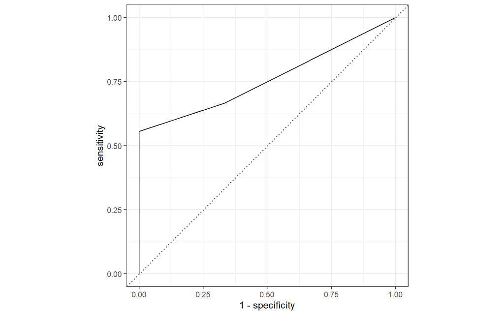

```r
final_boosted_model %>%
  predict(bake(tidy_rec, new_data = tidy_test), type = "prob") %>%
  bind_cols(tidy_test) %>%
  roc_curve(factor(Order), .pred_Anura) %>%
  autoplot()
```

## Evaluating knn model

```r
final_knn_model %>%
  predict(bake(tidy_rec, new_data = tidy_test), type = "prob") %>%
  bind_cols(tidy_test) %>%
  roc_auc(factor(Order), .pred_Anura)
```

```
## # A tibble: 1 x 3
##   .metric .estimator .estimate
##   <chr>   <chr>          <dbl>
## 1 roc_auc binary           0.5
```

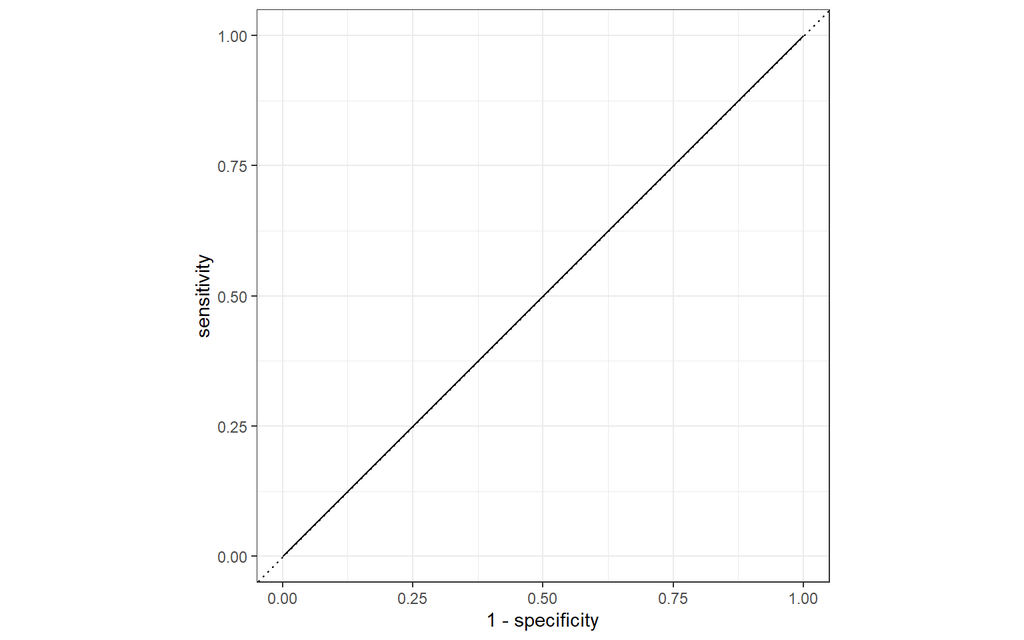

```r
final_knn_model %>%
  predict(bake(tidy_rec, new_data = tidy_test), type = "prob") %>%
  bind_cols(tidy_test) %>%
  roc_curve(factor(Order), .pred_Anura) %>%
  autoplot()
```

```r
final_knn_model %>%
  predict(bake(tidy_rec, new_data = tidy_test), type = "prob") %>%
  bind_cols(tidy_test) %>%
  roc_auc(factor(Order), .pred_Anura)
```

```
## # A tibble: 1 x 3
##   .metric .estimator .estimate
##   <chr>   <chr>          <dbl>
## 1 roc_auc binary           0.5
```

## Visualizing predictions:

```r
library(viridis)
```

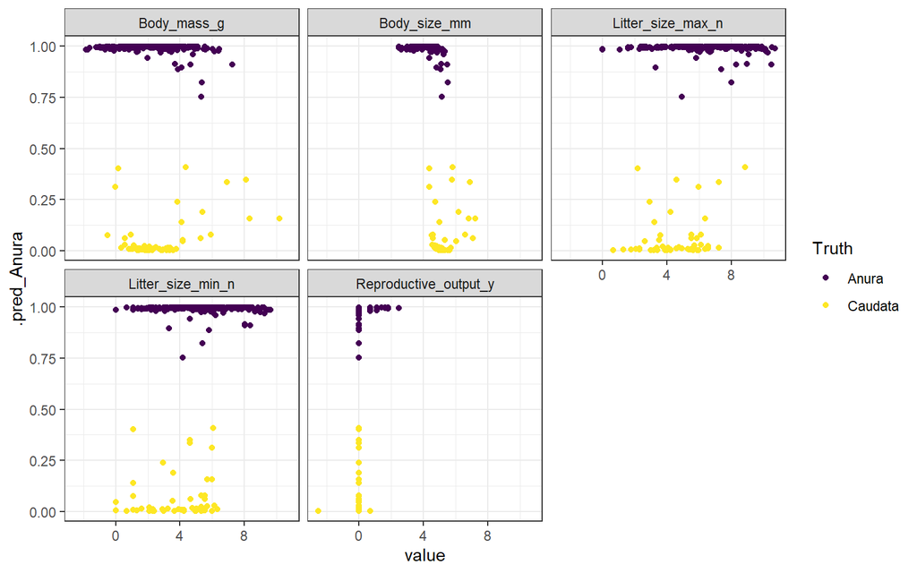

```r
ggplot(boosted_aug_long, aes(x = value, y = .pred_Anura, col = .pred_class)) +
  geom_point() +
  facet_wrap(~predictor) +
  scale_color_viridis_d("Truth", option = "D") +
  theme_bw()
```

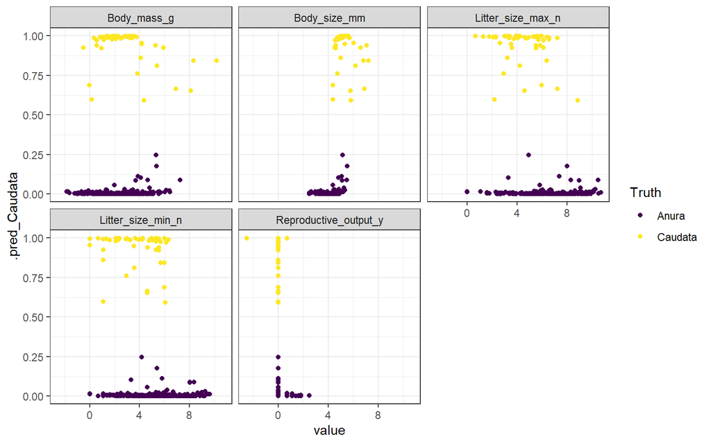

```r
ggplot(boosted_aug_long, aes(x = value, y = .pred_Caudata, col = .pred_class)) +
  geom_point() +
  facet_wrap(~predictor) +
  scale_color_viridis_d("Truth", option = "D") +
  theme_bw()
```